# League of Legends Game Win Analysis

#### (Patch 12.8)

## Contents

1. Introduction
2. Gathering Data
3. Analyzing Gold Advantage of the Winning Team
4. Impact of Baron
5. Impacts of Other Objectives  
   5.1 Inhibitors  
   5.2 Rift Herald  
   5.3 Dragon  
   5.4 Win Percentage Comparison
6. Using Machine Learning to Predict the Winner of a Game  
   6.1 Multiple Holdout Sets
7. ADC Itemization  
   7.1 Item Win Rates  
   7.2 Item Pick Rates
8. Conclusion
9. Appendix  
   9.1 API Calls to Gather Data

## Introduction

League of Legends is currently the largest Multiplayer Online Battle Arena (MOBA) video game, developed by Riot Games. Each match is comprised of two teams of five players. Each team is tasked with destroying the Nexus of the opposing team, and the first to do so wins the game. The Nexus is located in the heart of each team's base, making it difficult to get to. Along with advantages arising from fighting other players, there are also neutral objectives on the map that either team may take. These neutral objectives are located somewhat centrally so each team has a relatively equal chance of taking them. Neutral objectives grant some type of buff or other unique advantage with the goal of favoring the team that takes said objective.

I chose this dataset because I play League of Legends and have always been curious about what the most important aspects of the game are, statistically. I chose to use data from Challenger matches because Challenger represents the top 200 players on a given server (in this case, North America). Since these players are ranked so highly, they will play the game more optimally than those in lower ranks. Analyzing this data will more accurately show the impacts of objectives and item choices on the outcome of the game.

In this tutorial, my goal is to show how raw data obtained from Riot's API can be processed and how to extract the data we care about. I want to show how different aspects of the game affect the outcome of the game, including gold difference, objectives taken, and even item choices.

## Gathering Data

In order to get data to analyze, I made a [Riot Developer Account](https://developer.riotgames.com/) and applied for an API key for this project. I needed to get approved to make this project because the default development API key expires every 24 hours, while a project key lasts indefinitely. This allows me to update the data for every new update and keep the analysis consistent even when the meta changes. Having an approved project also allows me to apply to get an API key with higher rate limits than the default, which would allow me to collect much more data in a shorter amount of time from the [Riot API](https://developer.riotgames.com/apis). For the sake of brevity, I will skip over the code I used to actually collect my data from the Riot API. If you are interested in the process of obtaining the match data I used, I have included all the code I used to get the match data for my analysis along with a description of the process in an appendix at the bottom of this page.

We will start by importing Python3 libraries useful to us. The documentation for the most important ones can be found here: [numpy](https://numpy.org/doc/stable/), [pandas](https://pandas.pydata.org/pandas-docs/stable/), [matplotlib](https://matplotlib.org/), [scikit-learn](https://scikit-learn.org/stable/), and [seaborn](https://seaborn.pydata.org/)

```python
import numpy as np
import pandas as pd
import requests
import time
import os
import ast
import matplotlib.pyplot as plt
from sklearn.model_selection import train_test_split
from sklearn.discriminant_analysis import LinearDiscriminantAnalysis
import seaborn as sns
import random
```

Again, if you are interested in how to get this data, I have included a tutorial in an appendix at the bottom of this page.

For now, let's load the match data into a dataframe.

```python
match_data = pd.read_csv('match_data.csv').drop(['Unnamed: 0'], axis=1)
```

Note that 'info.participants' and 'info.teams' are nested data structures. This adds a layer of complication to working with the data. We will use these columns a lot for this analysis, hence why match_data is loop iterated often as we move forward.

```python
match_data.head()
```

|  | metadata.dataVersion | metadata.matchId | metadata.participants | info.gameCreation | info.gameDuration | info.gameEndTimestamp | info.gameId | info.gameMode | info.gameName | info.gameStartTimestamp | info.gameType | info.gameVersion | info.mapId | info.participants | info.platformId | info.queueId | info.teams | info.tournamentCode |
| --- | --- | --- | --- | --- | --- | --- | --- | --- | --- | --- | --- | --- | --- | --- | --- | --- | --- | --- |
| 0 | 2 | NA1_4299914395 | ['YRa0ow-1rSLpZNvI7G9RgVaRXpFmNp6M4w8dvgVq8r2R... | 1651911929000 | 1252 | 1651913207239 | 4299914395 | CLASSIC | teambuilder-match-4299914395 | 1651911954336 | MATCHED_GAME | 12.8.437.6765 | 11 | [{'assists': 6, 'baronKills': 0, 'bountyLevel'... | NA1 | 440 | [{'bans': [{'championId': 157, 'pickTurn': 1},... | NaN |
| 1 | 2 | NA1_4299940577 | ['IPBVEQKL_GYnH3tYuuw0oYFGgvum52jt9WKOCDLyheP8... | 1651910092000 | 1405 | 1651911523605 | 4299940577 | CLASSIC | teambuilder-match-4299940577 | 1651910117620 | MATCHED_GAME | 12.8.437.6765 | 11 | [{'assists': 2, 'baronKills': 0, 'bountyLevel'... | NA1 | 440 | [{'bans': [{'championId': 23, 'pickTurn': 1}, ... | NaN |
| 2 | 2 | NA1_4299874044 | ['ybpApu744780iGOv_SraxkjVxndBu3wLQ_KspSiB6nCp... | 1651907390000 | 1882 | 1651909301310 | 4299874044 | CLASSIC | teambuilder-match-4299874044 | 1651907418888 | MATCHED_GAME | 12.8.437.6765 | 11 | [{'assists': 10, 'baronKills': 0, 'bountyLevel... | NA1 | 440 | [{'bans': [{'championId': 164, 'pickTurn': 1},... | NaN |
| 3 | 2 | NA1_4299792505 | ['lmuRqyMeRCE5vEH10gJE0GiBls9vNYE2SK0Ccl6ajGEA... | 1651905083000 | 1741 | 1651906856770 | 4299792505 | CLASSIC | teambuilder-match-4299792505 | 1651905115316 | MATCHED_GAME | 12.8.437.6765 | 11 | [{'assists': 10, 'baronKills': 0, 'bountyLevel... | NA1 | 440 | [{'bans': [{'championId': 45, 'pickTurn': 1}, ... | NaN |
| 4 | 2 | NA1_4299320132 | ['QzjA5aZ3UnfGbRkE0IZ82rL4uJ7uTFEMcQpFhiVlovSe... | 1651883180000 | 1750 | 1651884968232 | 4299320132 | CLASSIC | teambuilder-match-4299320132 | 1651883217565 | MATCHED_GAME | 12.8.437.6765 | 11 | [{'assists': 5, 'baronKills': 0, 'bountyLevel'... | NA1 | 420 | [{'bans': [{'championId': 39, 'pickTurn': 1}, ... | NaN |

Before moving forward, lets drop all games that are not matchmade and all matches that are not classic Summoner's Rift (League of Legends' main and competitive game mode).

```python
match_data = (match_data[match_data['info.gameType'] == 'MATCHED_GAME']).reset_index(drop=True)
match_data = (match_data[match_data['info.gameMode'] == 'CLASSIC']).reset_index(drop=True)
```

```python
len(match_data)
```

```
11523
```

Great! We have data from 11,523 Challenger games we can analyze.

## Analyzing Gold Advantage of the Winning Team

One of the tricky parts of working with the data returned from the Riot API is that there are several nested JSONs within the main JSON returned, and extracting them from the main dataframe to their own dataframes for processing can sometimes be a pain.

```python
match_data['Gold Difference'] = 0
for index, match in match_data.iterrows():
    #get player data from current match
    #the nested json was saved as a string, so we must use a parser to get the data into something pandas can read
    players = pd.DataFrame(ast.literal_eval(match['info.participants'][1:-1]))
    winning_gold = sum(players[players['win']]['goldEarned'])
    losing_gold = sum(players[players['win'] == False]['goldEarned'])
    match_data.loc[index, 'Gold Difference'] = winning_gold-losing_gold
```

With the ending gold advantage calculated for the winning team of each match, we can plot it so we can visualize how it varies with the total duration of the match.

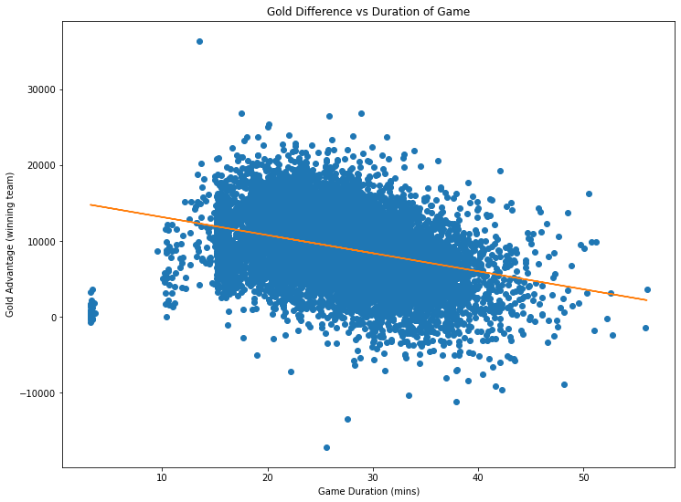

```python
x = match_data['info.gameDuration'] / 60
y = match_data['Gold Difference']
f, ax = plt.subplots(figsize=(12,9))
plt.plot(x, y, 'o')

# calculate linear fit line
m, b = np.polyfit(x, y, 1)
plt.plot(x, m*x+b)
plt.xlabel('Game Duration (mins)')
plt.ylabel('Gold Advantage (winning team)')
plt.title('Gold Difference vs Duration of Game')
plt.show()
```

The linear fit line shows a downward trend as the total duration of the match increases. This means that as the game goes longer, there is less of an advantage between the two teams, meaning the game is closer. Intuitively, this makes sense because in games where one team gets a very large advantage early in the game, it is expected that they will end the game more quickly. However, in games where the gold is close, both teams are more evenly matched and therefore the game will typically take longer as one team is not strong enough to defeat the other team entirely.

## Impact of Baron

Baron is a very important objective in League of Legends. Defeating Baron grants all champions on your team a buff that grants combat power as well as empowers your minions when you are nearby. Empowered minions make taking towers much easier and therefore gives you an advantage while you have the buff. Here we will calculate the win rate of taking Baron under different circumstances.

```python
baron_win = 0
baron_multiple_win = 0
baron_multiple_total = 0
baron_loss = 0
first_baron_win = 0
baron_total = 0
for index, match in match_data.iterrows():
    #get team data from current match
    teams = pd.DataFrame(ast.literal_eval(match['info.teams'][1:-1]))
    objectives0 = pd.DataFrame(teams['objectives'][0])
    objectives1 = pd.DataFrame(teams['objectives'][1])

    if teams['win'][0] == True :
        if objectives0['baron'][0]:
            first_baron_win += 1
        if objectives0['baron'][1] > 0:
            if objectives0['baron'][1] > 1:
                baron_multiple_win += 1
                baron_multiple_total += 1
            baron_win += 1
            baron_total += 1

        if objectives1['baron'][1] > 0:
            if objectives1['baron'][1] > 1:
                baron_multiple_total += 1
            baron_total += 1
            baron_loss += 1
    else:
        if objectives1['baron'][0] == True:
            first_baron_win += 1
        if objectives1['baron'][1] > 0:
            if objectives1['baron'][1] > 1:
                baron_multiple_win += 1
                baron_multiple_total += 1
            baron_win += 1
            baron_total += 1

        if objectives0['baron'][1] > 0:
            if objectives0['baron'][1] > 1:
                baron_multiple_total += 1
            baron_total += 1
            baron_loss += 1
```

Now let's plot these win rates so we can visualize how Baron buff impacts the outcome of these games.

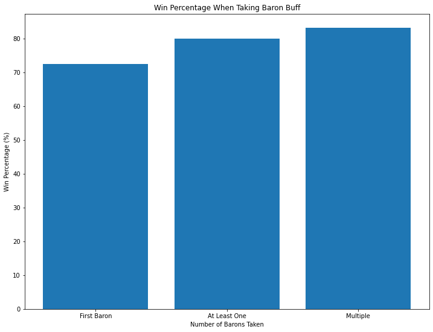

```python
x_axis = ['First Baron', 'At Least One', 'Multiple']
y_axis = [first_baron_win / baron_total * 100, baron_win / baron_total * 100, baron_multiple_win / baron_multiple_total * 100]

f, ax = plt.subplots(figsize=(12,9))
plt.bar(x_axis,y_axis)
plt.title('Win Percentage When Taking Baron Buff')
plt.xlabel('Number of Barons Taken')
plt.ylabel('Win Percentage (%)')
plt.show()
```

This plot makes sense because a winning team is most likely in a postion that taking Baron would further their advantage, and make it easier to end the game. Taking several Barons just continues to build an advantage, and typically a team is already in a winning state if they can safely take Baron.

## Impacts of Other Objectives

### Inhibitors

Another objective that is very important in League of Legends are a team's inhibitors (each team has 3). Located in the team's base, taking these structures down causes super minions to spawn against the team that loses them. Super minions are significantly harder to kill than regular minions and are more effective at applying pressure against the team with the broken inhibitor. Let's calculate the win rate of the team that takes one of the other's inhibitors first (don't worry, we will plot it later).

```python
first_inhib_win = 0
total_inhib = 0

for index, match in match_data.iterrows():
    #get team data from current match
    teams = pd.DataFrame(ast.literal_eval(match['info.teams'][1:-1]))
    objectives0 = pd.DataFrame(teams['objectives'][0])
    objectives1 = pd.DataFrame(teams['objectives'][1])
    if teams['win'][0] == True and objectives0['inhibitor'][0] == True:
        first_inhib_win += 1
        total_inhib += 1
    if teams['win'][1] == True and objectives1['inhibitor'][0] == True:
        first_inhib_win += 1
        total_inhib += 1
    if teams['win'][0] == False and objectives1['inhibitor'][0] == True:
        total_inhib += 1
    if teams['win'][1] == False and objectives1['inhibitor'][0] == True:
        total_inhib += 1
```

### Rift Herald

The Rift Herald is a neutral objective (similar to Baron) that is available early on in the match (from 8 - 20 minutes). Defeating the Rift Herald allows your team to summon the Rift Herald which will charge at the nearest tower, doing a large amount of damage. We will also calculate the win rate after taking at least one Rift Herald.

```python
rift_win = 0
total_rift = 0

for index, match in match_data.iterrows():
    #get team data from current match
    teams = pd.DataFrame(ast.literal_eval(match['info.teams'][1:-1]))
    objectives0 = pd.DataFrame(teams['objectives'][0])
    objectives1 = pd.DataFrame(teams['objectives'][1])
    if teams['win'][0] == True and objectives0['riftHerald'][1] > 0:
        rift_win += 1
        total_rift += 1
    if teams['win'][1] == True and objectives1['riftHerald'][0] > 0:
        rift_win += 1
        total_rift += 1
    if teams['win'][0] == False and objectives1['riftHerald'][0] > 0:
        total_rift += 1
    if teams['win'][1] == False and objectives1['riftHerald'][0] > 0:
        total_rift += 1
```

### Dragon

Lastly, we will look at taking the first dragon. Dragon is the last objective we will look at. Dragons grant small buffs that last for the remainder of the match. The advantage gained from a single drake is not very large, but it is relatively consistent. Note that we will only look at the win rate after taking the first dragon, so stacking drakes will not be considered.

```python
first_dragon_win = 0
total_dragon = 0

for index, match in match_data.iterrows():
    #get team data from current match
    teams = pd.DataFrame(ast.literal_eval(match['info.teams'][1:-1]))
    objectives0 = pd.DataFrame(teams['objectives'][0])
    objectives1 = pd.DataFrame(teams['objectives'][1])
    if teams['win'][0] == True and objectives0['dragon'][0] == True:
        first_dragon_win += 1
        total_dragon += 1
    if teams['win'][1] == True and objectives1['dragon'][0] == True:
        first_dragon_win += 1
        total_dragon += 1
    if teams['win'][0] == False and objectives1['dragon'][0] == True:
        total_dragon += 1
    if teams['win'][1] == False and objectives1['dragon'][0] == True:
        total_dragon += 1
```

### Win Percentage Comparison

Plotting the win percentages of these objectives can show intuitively which objectives have the most impact on the outcome of the game.

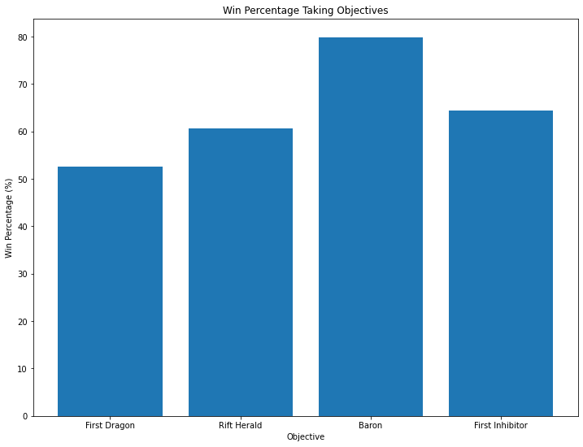

```python
x_axis = ['First Dragon', 'Rift Herald', 'Baron', 'First Inhibitor']
y_axis = [first_dragon_win / total_dragon * 100, rift_win / total_rift * 100, baron_win / baron_total * 100, first_inhib_win / total_inhib * 100]

f, ax = plt.subplots(figsize=(12,9))
plt.bar(x_axis,y_axis)
plt.title('Win Percentage Taking Objectives')
plt.xlabel('Objective')
plt.ylabel('Win Percentage (%)')
plt.show()
```

From this plot, we can see that Baron has the highest impact on the outcome of the game. This is not very surprising considering how strong the buff from this objective is. It is not surprising that taking first dragon does not impact the game very much, as the buff is relatively weak. Taking this buff early does not net a win rate much above 50%. A 50% win percentage would mean that this objective has no impact on the outcome of the game, as wins and losses would average out to roughly 50%.

## Using Machine Learning to Predict the Winner of a Game

Here we will perform a Linear Discriminant Analysis on objective variables to see if we can predict a win.

```python
win_lose = pd.DataFrame()
objective_info = pd.DataFrame()

for index, match in match_data.iterrows():
    #get team data from current match
    teams = pd.DataFrame(ast.literal_eval(match['info.teams'][1:-1]))
    win_lose = pd.concat([win_lose, teams['win']])
    objectives0 = pd.DataFrame(teams['objectives'][0])
    objectives1 = pd.DataFrame(teams['objectives'][1])

    # need to concat a series to empty dataframe and transpose to format correctly before concatenating to main df
    temp_df = pd.concat([pd.DataFrame(), objectives0.iloc[1]]).T
    objective_info = pd.concat([objective_info, temp_df])

    temp_df = pd.concat([pd.DataFrame(), objectives1.iloc[1]]).T
    objective_info = pd.concat([objective_info, temp_df])

win_lose.reset_index(inplace=True, drop=True)
objective_info.reset_index(inplace=True, drop=True)
win_lose.rename(columns={0:'win'}, inplace=True)
```

Now we have a dataframe containing independent variables (objectives) from each team which provide different advantages for that team in game. We also have another dataframe corresponding to whether the given team (matching row) won the match or not. We are now ready to perform a Linear Discriminant Analysis to see if we can accurately predict the outcome of a game given objectives taken.

We will determine how effective our analysis is by performing holdout validation on our dataset. The model will be trained using 80% of our data, and the remaining 20% will become the test data which our model will try to predict the outcome, and this prediction will be compared against the true outcome in order to determine how accurate the model is.

```python
# Split data into a training and test set so we can perform holdout validation
x_train, x_test, y_train, y_test = train_test_split(objective_info, win_lose, test_size = 0.2, random_state = 987)

# Format the data so it can be used by Scikit's LinearDiscriminantAnalysis
x_train_arr = x_train[['baron', 'champion', 'dragon', 'inhibitor', 'riftHerald', 'tower']].to_numpy()
y_train_arr = y_train[['win']].values.ravel()
y_train_arr = np.array(y_train_arr, dtype=bool)

clf = LinearDiscriminantAnalysis()
clf.fit(x_train_arr, y_train_arr)
```

```
LinearDiscriminantAnalysis()
```

With the model trained, we can use the test set to predict the outcome of each of those games and evaluate the accuracy of the model.

```python
win_pred = clf.predict(x_test[['baron', 'champion', 'dragon', 'inhibitor', 'riftHerald', 'tower']].to_numpy())
win_pred = pd.DataFrame(win_pred).rename(columns={0:'prediction'})
prediction_outcome = pd.concat([y_test.reset_index(drop=True), win_pred], axis=1)
```

Since the prediction consists of a categorical outcome (win / lose), we can determine the accuracy of the model as a percentage of how many the model classified correctly.

```python
percent_right = sum(prediction_outcome['win'] == prediction_outcome['prediction']) / len(prediction_outcome.index) * 100
percent_right
```

```
84.25162689804773
```

Great! Using this model on our test set, we had an 84% correct prediction rate, meaning we used the model to predict the outcome on the remaining 20% of our data, and 84% of those predictions were correct. However, this could be and outlier due to a lucky choice in the training set and test set. Let's run our analysis a few more times, separating the data into different combinations of training sets and test sets to see what the accuracy of our model is, on average.

### Multiple Holdout Sets

```python
# initialize our x and y arrays for future plot
holdout_iter = [1]
model_accuracy = [percent_right]
```

In order to get a unique combination of training and test sets, we can use a random number generator to generate different seeds for the train-test splitter method every time we run it.

```python
# set random seed so output is consistent
random.seed(43687962)
for i in range(1, 50):

    # Split data into a training and test set so we can perform holdout validation
    # This time, use random number generator to generate seed, therefore getting different sets of training and test data
    x_train, x_test, y_train, y_test = train_test_split(objective_info, win_lose, test_size = 0.2, random_state = random.randint(1, 9999999))

    # Format the data so it can be used by Scikit's LinearDiscriminantAnalysis
    x_train_arr = x_train[['baron', 'champion', 'dragon', 'inhibitor', 'riftHerald', 'tower']].to_numpy()
    y_train_arr = y_train[['win']].values.ravel()
    y_train_arr = np.array(y_train_arr, dtype=bool)

    clf = LinearDiscriminantAnalysis()
    clf.fit(x_train_arr, y_train_arr)

    win_pred = clf.predict(x_test[['baron', 'champion', 'dragon', 'inhibitor', 'riftHerald', 'tower']].to_numpy())
    win_pred = pd.DataFrame(win_pred).rename(columns={0:'prediction'})
    prediction_outcome = pd.concat([y_test.reset_index(drop=True), win_pred], axis=1)

    # calculate accuracy
    percent_right = sum(prediction_outcome['win'] == prediction_outcome['prediction']) / len(prediction_outcome.index) * 100

    # add to our x and y arrays
    model_accuracy.append(percent_right)
    holdout_iter.append(i + 1)
```

Each model prediction accuracy is saved, so we can plot it to visualize how well our models performed.

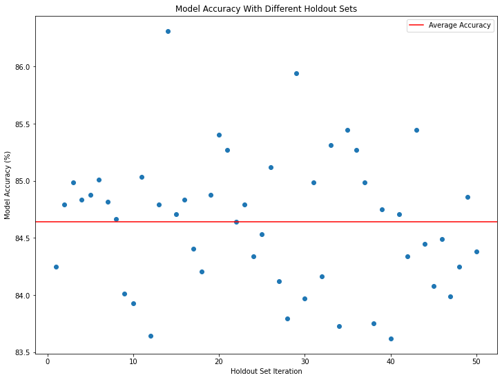

```python
# calculate average model accuracy
avg_accuracy = sum(model_accuracy)/len(model_accuracy)

f, ax = plt.subplots(figsize=(12,9))
plt.plot(holdout_iter, model_accuracy, 'o')

# plot horizontal line at average accuracy
plt.axhline(y=avg_accuracy, color='r', linestyle='-', label='Average Accuracy')
plt.legend()
plt.title('Model Accuracy With Different Holdout Sets')
plt.xlabel('Holdout Set Iteration')
plt.ylabel('Model Accuracy (%)')
plt.show()
```

On average, the model we generate has about an 84-85% accuracy, so we have confirmed that the first model was not an outlier! These models are pretty accurate, but they could definitely be better. These models only take into account one team's objectives at a time and then attempts to determine whether that team won the game. A better model could take in the game state of both teams and evaluate both of their objectives taken together. Then, it would determine the winner and loser of the two. This way, the model could evaluate relative advantages of one team over another, resulting in more accurate predictions.

## ADC Itemization

Items are a core part of League of Legends. As players earn gold (via farming minions, champion kills/assists, turret kills, etc), they spend the gold on items which provide stats and benefits that augment their champion and playstyle, making them stronger. With the item rework at the start of Season 11, completed items were classified into two main categories, Mythic and Legendary; the former being significantly stronger than the latter. The catch is each player can only build one Mythic item per game. As an Attack Damage Carry (ADC) player, I have always wondered what the most effective mythic item to build is. Traditional ADCs typically build one of three Mythic items: Kraken Slayer, Galeforce, or Shieldbow. Kraken Slayer grants the user an empowered attack every 3rd attack which does bonus damage; Galeforce grants the user a dash, allowing them to reposition quickly or escape an attacker; and Shieldbow gives the user a large shield for a short time when they take a lot of damage, increasing the champion's durability.

### Item Win Rates

Let's find the win rate of each item on each ADC champion and plot it. First, we'll declare a list of the ID every ADC we want to analyze so we know which row from the dataframe we want to look at.

```python
adc_ids = [523, 22, 51, 119, 202, 222, 145, 429, 96, 236, 21, 360, 15, 18, 29, 110, 67, 498, 221]
```

Now we need a dataframe to hold the data we want to capture from the main match data.

```python
adc_items = pd.DataFrame(adc_ids)
adc_items.rename(columns={ 0 :'Champion Id'}, inplace=True)
adc_items['Champion Name'] = 'No Data'
adc_items['Kraken Slayer Win Rate'] = 0
adc_items['Galeforce Win Rate'] = 0
adc_items['Shieldbow Win Rate'] = 0
adc_items['Kraken Slayer Wins'] = 0
adc_items['Galeforce Wins'] = 0
adc_items['Shieldbow Wins'] = 0
adc_items['Kraken Slayer Total'] = 0
adc_items['Galeforce Total'] = 0
adc_items['Shieldbow Total'] = 0
```

In order to get the win rate of each item on each champion, we need to count how many times a champion has been played with an item and how many times that champion has won using that item.

```python
for index, match in match_data.iterrows():
    #get player data from current match
    players = pd.DataFrame(ast.literal_eval(match['info.participants'][1:-1]))

    #make a dataframe of only adcs in current match
    curr_adcs = pd.DataFrame()
    for ad in adc_ids:
        curr_adcs = pd.concat([curr_adcs, players[players['championId'] == ad]])

    #find which adc each one corresponds to and update item counts accordingly
    for i, summoner in curr_adcs.iterrows():
        idx = adc_items[adc_items['Champion Id'] == summoner['championId']].index[0]
        if summoner['item1'] == 6671:
            adc_items.loc[idx, 'Galeforce Total'] += 1
            if summoner['win'] == True:
                adc_items.loc[idx, 'Galeforce Wins'] += 1
        elif summoner['item1'] == 6672:
            adc_items.loc[idx, 'Kraken Slayer Total'] += 1
            if summoner['win'] == True:
                adc_items.loc[idx, 'Kraken Slayer Wins'] += 1
        elif summoner['item1'] == 6673:
            adc_items.loc[idx, 'Shieldbow Total'] += 1
            if summoner['win'] == True:
                adc_items.loc[idx, 'Shieldbow Wins'] += 1

        #using the data to fill in the champion names because it's more efficient than looking them all up in the api
        if adc_items.loc[idx, 'Champion Name'] == 'No Data':
            adc_items.loc[idx, 'Champion Name'] = summoner['championName']

#calculate the win rate of each item
adc_items['Kraken Slayer Win Rate'] = adc_items['Kraken Slayer Wins'] / adc_items['Kraken Slayer Total']
adc_items['Galeforce Win Rate'] = adc_items['Galeforce Wins'] / adc_items['Galeforce Total']
adc_items['Shieldbow Win Rate'] = adc_items['Shieldbow Wins'] / adc_items['Shieldbow Total']
#fill in .5 for missing data so the missing entries do not show up as extreme outliers on the plot
#adc_items.fillna(0.5, inplace=True)
```

```python
adc_items
```

|  | Champion Id | Champion Name | Kraken Slayer Win Rate | Galeforce Win Rate | Shieldbow Win Rate | Kraken Slayer Wins | Galeforce Wins | Shieldbow Wins | Kraken Slayer Total | Galeforce Total | Shieldbow Total |
| --- | --- | --- | --- | --- | --- | --- | --- | --- | --- | --- | --- |
| 0 | 523 | Aphelios | 0.562500 | 0.470175 | 0.416667 | 9 | 134 | 5 | 16 | 285 | 12 |
| 1 | 22 | Ashe | 0.581395 | 0.606061 | 0.421053 | 25 | 40 | 16 | 43 | 66 | 38 |
| 2 | 51 | Caitlyn | 0.666667 | 0.513812 | 0.636364 | 12 | 93 | 7 | 18 | 181 | 11 |
| 3 | 119 | Draven | 0.769231 | 0.272727 | 0.543478 | 10 | 3 | 25 | 13 | 11 | 46 |
| 4 | 202 | Jhin | NaN | 0.467925 | NaN | 0 | 248 | 0 | 0 | 530 | 0 |
| 5 | 222 | Jinx | 0.500000 | 0.543478 | 0.428571 | 121 | 200 | 3 | 242 | 368 | 7 |
| 6 | 145 | Kaisa | 0.561983 | 0.435897 | 0.500000 | 68 | 17 | 1 | 121 | 39 | 2 |
| 7 | 429 | Kalista | 0.750000 | 0.500000 | 0.528302 | 3 | 2 | 28 | 4 | 4 | 53 |
| 8 | 96 | KogMaw | 0.000000 | 0.666667 | 0.571429 | 0 | 2 | 4 | 3 | 3 | 7 |
| 9 | 236 | Lucian | 0.504854 | 0.495798 | 0.333333 | 52 | 236 | 1 | 103 | 476 | 3 |
| 10 | 21 | MissFortune | 0.575758 | 0.800000 | 0.000000 | 19 | 8 | 0 | 33 | 10 | 4 |
| 11 | 360 | Samira | NaN | 0.627451 | 0.473684 | 0 | 32 | 135 | 0 | 51 | 285 |
| 12 | 15 | Sivir | 0.600000 | 0.555556 | 0.000000 | 6 | 10 | 0 | 10 | 18 | 1 |
| 13 | 18 | Tristana | 0.488189 | 0.533333 | 0.500000 | 62 | 16 | 2 | 127 | 30 | 4 |
| 14 | 29 | Twitch | 0.411765 | 0.509091 | NaN | 21 | 28 | 0 | 51 | 55 | 0 |
| 15 | 110 | Varus | 0.250000 | 0.400000 | 0.000000 | 2 | 4 | 0 | 8 | 10 | 1 |
| 16 | 67 | Vayne | 0.471698 | 0.625000 | 0.520833 | 25 | 5 | 75 | 53 | 8 | 144 |
| 17 | 498 | Xayah | 0.222222 | 0.515625 | 0.000000 | 2 | 33 | 0 | 9 | 64 | 1 |
| 18 | 221 | Zeri | 0.466667 | 1.000000 | 0.561224 | 14 | 1 | 55 | 30 | 1 | 98 |

Because we are looking to make a heatmap, the dataframe must be specifically formatted in order to be used by the heatmap method. We need a dataframe of only the champions and item win rates (with item titles).

```python
item_winrates = adc_items[['Champion Name', 'Kraken Slayer Win Rate', 'Galeforce Win Rate', 'Shieldbow Win Rate']].copy()
item_winrates.rename(columns={'Champion Name':'Champion', 'Kraken Slayer Win Rate':'Kraken Slayer', 'Galeforce Win Rate':'Galeforce', 'Shieldbow Win Rate':'Shieldbow'}, inplace=True)
```

Now we can melt those individual item columns into one column.

```python
item_winrates = pd.melt(item_winrates, id_vars='Champion', var_name='Item', value_name='Win Rate')
item_winrates.head()
```

|  | Champion | Item | Win Rate |
| --- | --- | --- | --- |
| 0 | Aphelios | Kraken Slayer | 0.562500 |
| 1 | Ashe | Kraken Slayer | 0.581395 |
| 2 | Caitlyn | Kraken Slayer | 0.666667 |
| 3 | Draven | Kraken Slayer | 0.769231 |
| 4 | Jhin | Kraken Slayer | NaN |

This dataframe is ready to be plotted as a heatmap.

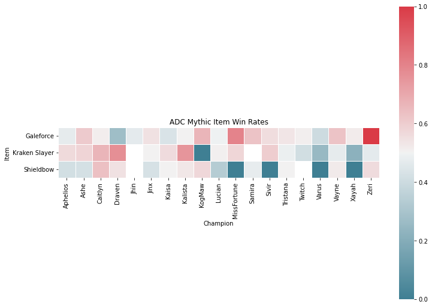

```python
cmap = sns.diverging_palette(220, 10, as_cmap=True)
pivot = item_winrates.pivot(index='Item', columns='Champion', values='Win Rate')
f, ax = plt.subplots(figsize=(12,9))
sns.heatmap(pivot, cmap=cmap, square=True, linewidths=.5)
plt.title('ADC Mythic Item Win Rates')
plt.show()
```

This plot is very interesting, as we can see how certain champions may synergize better with one Mythic item over another. For example, Miss Fortune has higher win rates when building both Galeforce and Kraken Slayer over building Shieldbow. Miss Fortune's damage is more burst-focused, and therefore she benefits from having the extra burst damage from empowered Kraken Slayer auto attacks and from the Galeforce execute dash-projectiles. Another champion to look at is Ashe. By default, Ashe does not do a lot of damage compared to most other ADCs. However, Ashe has a lot more utility at her disposal than most other ADCs, allowing her to set her team up for success. Because she does not do a lot of damage on her own, she benefits heavily from building Mythics that allow her to do more damage, covering her biggest weakness. Shieldbow is not very useful on Ashe because staying alive longer in a fight does not matter when you do not do enough damage to be a threat.

The flaw with this map is it may misrepresent some champions, as the sample size for many of the champions shown is quite small. The meta also effects how this plot looks. During any given meta, roughly 4-5 ADCs are played at a significantly higher rate than the other ADCs. In this meta, Jinx has a very large sample size because she is in meta on the current patch, while a champion like KogMaw only has a few games played because they are not in meta. Another misrepresentation in this data is known optimal builds on specific champions. For example, Vayne has a massive amount of damage built into her kit (due to her champion abilities) by default. Because of this, almost everyone builds Shieldbow on her because it helps you stay alive longer and she does not benefit much from the extra damage the other Mythics would grant. However, looking at this plot, you would think that you should be building Galeforce on Vayne because it is a higher win rate, when in reality those are most likely outlier games where Vayne's team happened to win.

### Item Pick Rates

Now that we acknowledged possible flaws in this plot, lets make a new plot to show the play rate of each Mythic. Challenger players are good for a reason, so they must be making mostly optimal decisions with their item picks, right?

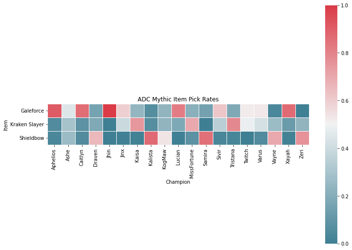

```python
adc_items['Total Plays'] = adc_items['Kraken Slayer Total'] + adc_items['Galeforce Total'] + adc_items['Shieldbow Total']
adc_items['Kraken Slayer Pick Rate'] = adc_items['Kraken Slayer Total'] / adc_items['Total Plays']
adc_items['Galeforce Pick Rate'] = adc_items['Galeforce Total'] / adc_items['Total Plays']
adc_items['Shieldbow Pick Rate'] = adc_items['Shieldbow Total'] / adc_items['Total Plays']

adc_picks = adc_items[['Champion Name', 'Kraken Slayer Pick Rate', 'Galeforce Pick Rate', 'Shieldbow Pick Rate']].copy()
adc_picks.rename(columns={'Champion Name':'Champion', 'Kraken Slayer Pick Rate':'Kraken Slayer', 'Galeforce Pick Rate':'Galeforce', 'Shieldbow Pick Rate':'Shieldbow'}, inplace=True)

adc_picks = pd.melt(adc_picks, id_vars='Champion', var_name='Item', value_name='Pick Rate')

cmap = sns.diverging_palette(220, 10, as_cmap=True)
pivot = adc_picks.pivot(index='Item', columns='Champion', values='Pick Rate')
f, ax = plt.subplots(figsize=(12,9))
sns.heatmap(pivot, cmap=cmap, square=True, linewidths=.5)
plt.title('ADC Mythic Item Pick Rates')
plt.show()
```

This plot gives us a better idea of what top players are building on each ADC and outlines the meta a bit more clearly. Using both this plot as well as the win rate plot we can make more informed decisions on which Mythic is most optimal to choose. If there are several Mythics with similar pick rates, it is most likely a game-dependant choice to make.

## Conclusion

While I made in-depth analyses into specific parts of League of Legends in this tutorial, this data will soon be obsolete as new patches come out and the meta shifts. Luckily, the code in this tutorial can be re-ran on new patches with new data and can then provide new insights.

I hope this tutorial provided insight into not only processing data from League of Legends, but processing large amounts of data as a whole. I showed data collection, cleaning and wrangling the data, visualizing it, and a bit of Machine Learning predictions. The data science pipeline can sometimes be intimidating, but breaking it down into managable chunks is key.

Riot's developer portal hosts significantly more APIs than the ones I used in this tutorial, so there is an entire sea of data that can be pulled related to League of Legends as well as other Riot Games (VALORANT, Legends of Runterra, etc.). Even within League of Legends data, I did not even scratch the surface of what can be done; match data can be pulled with a timeline of all events that happened during a match and when, even giving locational data. Also, I only used Challenger data whereas data can be pulled from every single player on a given server. I hope this inspires others to make other interesting analyses or applications. Thanks for reading!

# Appendix

## API Calls to Gather Data

The path to gathering match data from Challenger (top 200) players is a bit tedious. There is no way to directly make API calls for matches in this division on the leaderboard. Instead, we can request a list of the names and basic account information of these players.

(Note: most of the following code is commented so it is not making API calls when generating this webpage. Gathering this data is time-intensive due to the rate limit on my API key. This is also why all the data is written to csv files. These csv files are used to generate the analysis above.)

Save API keys in memory.

```python
# key_file = open('api_key.txt', 'r')
# api_key = key_file.readlines()
# my_region = 'na1'
# key_file.close()
```

```python
# chal_sample_url = 'https://na1.api.riotgames.com/lol/league/v4/challengerleagues/by-queue/RANKED_SOLO_5x5?api_key='+api_key[0]
# chal_sample_data = pd.read_json(chal_sample_url)
# chal_sample_data = pd.DataFrame(list(chal_sample_data['entries']))
# chal_sample_data.to_csv('chal_sample.csv', sep=',')
```

We cannot get their matches played yet, as we do not have the puuid of each player, which is used to lookup recent matches. However, now that we have the name and basic account info of each of these players, we can lookup the rest of their account information. The data that this API call returns will contain the puuid for each account.

```python
# secs_count = 0
# mins_count = 0
# df = pd.DataFrame()
# path = './'
# for index, summoner in chal_sample_data.iterrows():
#     need_to_process = True

#     while (need_to_process):
#         secs_count += 1
#         url = 'https://na1.api.riotgames.com/lol/summoner/v4/summoners/by-name/'+summoner['summonerName']+'?api_key='+api_key[0]

#         r = requests.get(url)

#         #throttle requests
#         if mins_count >= 7:
#             time.sleep(125)
#             mins_count = 0

#         elif r.status_code != 200:
#             if r.status_code == 429:
#                 print('too many requests')
#                 mins_count += 1

#             elif r.status_code == 404:
#                 print("Not found: " + str(summoner))
#                 need_to_process = False

#             else:
#                 print("Different error: " + str(r.status_code))
#                 need_to_process = False
#             time.sleep(2)
#             secs_count += 1

#         elif secs_count >= 18:
#             time.sleep(3)
#             secs_count = 0
#             mins_count += 1

#         else:
#             df = pd.json_normalize(r.json())
#             if not os.path.isfile('chall_accounts.csv'):
#                df.to_csv('chall_accounts.csv')

#             else:
#                df.to_csv('chall_accounts.csv', mode='a', header=False)
#             need_to_process = False



# print('done')
```

We have the puuid of each player, so now we can go through and request a list of match IDs for the 100 most recent matches played by each player. Because these players are at the very top of the leaderboard, it is likely that many of them play with/against each other. At the end, we need to drop all duplicate matches so we are only analyzing the data from a given match once.

```python
# secs_count = 0
# mins_count = 0
# df = pd.DataFrame()
# path = './'
# for index, summoner in chall_players.iterrows():
#     need_to_process = True

#     while (need_to_process):
#         secs_count += 1
#         url = 'https://americas.api.riotgames.com/lol/match/v5/matches/by-puuid/'+summoner['puuid']+'/ids?start=0&count=100&api_key='+api_key[0]

#         r = requests.get(url)

#         #throttle requests
#         if mins_count >= 7:
#             time.sleep(125)
#             mins_count = 0

#         elif r.status_code != 200:
#             if r.status_code == 429:
#                 print('too many requests')
#                 mins_count += 1

#             elif r.status_code == 404:
#                 print("Not found: " + str(summoner))
#                 need_to_process = False

#             else:
#                 print("Different error: " + str(r.status_code))
#                 need_to_process = False
#             time.sleep(2)
#             secs_count += 1

#         elif secs_count >= 18:
#             time.sleep(2)
#             secs_count = 0
#             mins_count += 1

#         else:
#             df= pd.DataFrame(r.json())
#             if not os.path.isfile('match_ids.csv'):
#                df.to_csv('match_ids.csv')

#             else:
#                df.to_csv('match_ids.csv', mode='a', header=False)
#             need_to_process = False



# matches = pd.read_csv('match_ids.csv').drop(['Unnamed: 0'], axis=1).drop_duplicates().reset_index(drop=True)
# matches.rename(columns={"0": "Match ID"}, inplace=True)
# matches.to_csv('match_ids.csv')
# print('done')
```

With these match IDs, we can now request our match data for recent matches from the top players.

```python
# secs_count = 0
# mins_count = 0
# df = pd.DataFrame()
# path = './'
# for index, match in matches.iterrows():
#     need_to_process = True

#     while (need_to_process):
#         secs_count += 1
#         url = 'https://americas.api.riotgames.com/lol/match/v5/matches/'+match['Match ID']+'?api_key='+api_key[0]

#         r = requests.get(url)

#         #throttle requests
#         if mins_count >= 7:
#             print('current match index: ' + str(index))
#             time.sleep(125)
#             mins_count = 0

#         elif r.status_code != 200:
#             if r.status_code == 429:
#                 print('too many requests')
#                 mins_count += 1

#             elif r.status_code == 404:
#                 print("Not found: " + str(match))
#                 need_to_process = False

#             else:
#                 print("Different error: " + str(r.status_code))
#                 need_to_process = False
#             time.sleep(2)
#             secs_count += 1

#         elif secs_count >= 18:
#             time.sleep(2)
#             secs_count = 0
#             mins_count += 1

#         else:
#             df = pd.json_normalize(r.json())

#             if not os.path.isfile('match_data.csv'):
#                df.to_csv('match_data.csv')
#             else:
#                df.to_csv('match_data.csv', mode='a', header=False)
#             need_to_process = False



# print('done')
```

Awesome! Now we have a csv file filled with thousands of matches from the top players and we are ready to start our analysis.